# Practice with nflfastR play-by-play data

April 17, 2025

## Resources:

- An nflfastR [beginner’s guide](https://www.nflfastr.com/articles/beginners_guide.html)
- Searchable [variable descriptions](https://www.nflfastr.com/articles/field_descriptions.html) for the 372 columns in the play-by-play data.

## Setup

- Create a new script.
- Record (as comment) your name in line 1.
- Load the tidyverse and nflfastR packages:

```r
library(tidyverse)
library(nflfastR)
library(kableExtra) # I also use kableExtra to generate nice tables
```

Then load play-by-play data for the 2024 regular season:

```r
df <- load_pbp(seasons = 2024) |>
  filter(season_type == 'REG')
```

## Questions

> **1.** Determine the distribution of yards lost by the offense for all sacks in the 2024 season

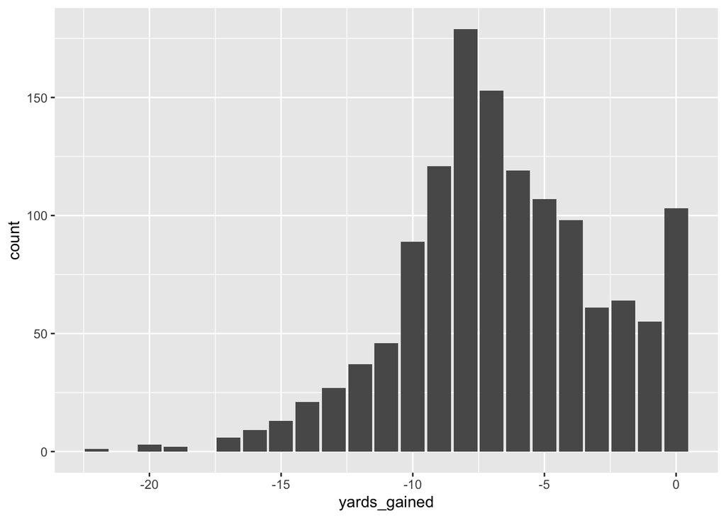

```r
sacks <- df |> filter(sack == 1)

ggplot(sacks, aes(x = yards_gained) )+
  geom_bar()
```

```r
#some quantitative descriptors of the distribution:
mean(sacks$yards_gained)
```

```
## [1] -6.579148
```

```r
sd(sacks$yards_gained)
```

```
## [1] 3.814658
```

```r
fivenum(sacks$yards_gained)
```

```
## [1] -22  -9  -7  -4   0
```

> **2.** Show the play descriptions in which Myles Garrett (player name ‘M.Garrett’) was awarded full credit for a sack. How many yards lost, on average for Garrett’s sacks?

```r
garrett <- df |>
  filter(sack == 1,sack_player_name == 'M.Garrett') |>
  select(week,home_team,away_team,desc,sack_player_name,yards_gained)

# nrow(garrett) #total number of sacks! - matches the number you'd find on nfl.com :)


garrett |>
  kbl(caption = paste("description of Garrett's", nrow(garrett), "sacks")) |>
  kable_minimal(full_width=F)
```

description of Garrett’s 14 sacks

| week | home_team | away_team | desc | sack_player_name | yards_gained |
| --- | --- | --- | --- | --- | --- |
| 1 | CLE | DAL | (14:27) (Shotgun) 4-D.Prescott sacked at DAL 24 for -7 yards (95-M.Garrett). FUMBLES (95-M.Garrett) [95-M.Garrett], recovered by DAL-1-J.Tolbert at DAL 24. | M.Garrett | -7 |
| 2 | JAX | CLE | (6:34) (Shotgun) 16-T.Lawrence sacked at CLE 26 for -9 yards (95-M.Garrett). FUMBLES (95-M.Garrett) [95-M.Garrett], touched at CLE 26, recovered by JAX-2-D.Johnson at CLE 25. ** Injury Update: CLE-23-… | M.Garrett | -9 |
| 4 | LV | CLE | (:50) (No Huddle, Shotgun) 15-G.Minshew sacked at LV 13 for -6 yards (95-M.Garrett). | M.Garrett | -6 |
| 4 | LV | CLE | (12:38) 75-A.Peat reported in as eligible. 15-G.Minshew sacked at LV 41 for -8 yards (95-M.Garrett). | M.Garrett | -8 |
| 9 | CLE | LAC | (1:45) (Shotgun) 10-J.Herbert sacked at LAC 15 for -6 yards (95-M.Garrett). | M.Garrett | -6 |
| 9 | CLE | LAC | (:26) (Shotgun) 10-J.Herbert sacked at LAC 5 for -8 yards (95-M.Garrett). | M.Garrett | -8 |
| 9 | CLE | LAC | (9:30) 10-J.Herbert sacked at LAC 28 for -2 yards (95-M.Garrett). | M.Garrett | -2 |
| 12 | CLE | PIT | (10:03) (Shotgun) 3-R.Wilson sacked at CLE 40 for -8 yards (95-M.Garrett). | M.Garrett | -8 |
| 12 | CLE | PIT | (3:19) 3-R.Wilson sacked at PIT 25 for -7 yards (95-M.Garrett). FUMBLES (95-M.Garrett), touched at PIT 28, RECOVERED by CLE-59-W.Reid at PIT 31. | M.Garrett | -4 |
| 12 | CLE | PIT | (:11) (No Huddle, Shotgun) 3-R.Wilson sacked at PIT 41 for -8 yards (95-M.Garrett). | M.Garrett | -8 |
| 14 | PIT | CLE | (3:48) (Shotgun) 3-R.Wilson sacked at PIT 21 for -11 yards (95-M.Garrett). | M.Garrett | -11 |
| 16 | CIN | CLE | (1:33) (No Huddle, Shotgun) 9-J.Burrow sacked at CLE 45 for -8 yards (95-M.Garrett). | M.Garrett | -8 |
| 17 | CLE | MIA | (8:54) (Shotgun) 18-T.Huntley sacked at MIA 30 for -7 yards (95-M.Garrett). | M.Garrett | -7 |
| 17 | CLE | MIA | (9:16) (No Huddle) 18-T.Huntley sacked at MIA 28 for 0 yards (95-M.Garrett). | M.Garrett | 0 |

```r
# average yards per sack - about matches the league average!
mean(garrett$yards_gained)
```

```
## [1] -6.571429
```

> **3.** Which defender with at least 8 sacks on the season averaged the most yards lost per sack?

```r
sacks |> group_by(sack_player_name,defteam) |>
  summarize(N = n(),
            yards_per_sack = mean(yards_gained)) |>
  filter(N >= 8) |>
  arrange(yards_per_sack) |>
  drop_na()  |> # some sack_player_name values are NA - if two player's each get 1/2 sack, for instance
  kbl(caption='sack leaders, by yards per sack') |>
  kable_classic(full_width=F)
```

sack leaders, by yards per sack

| sack_player_name | defteam | N | yards_per_sack |
| --- | --- | --- | --- |
| B.Fiske | LA | 8 | -10.875000 |
| J.Greenard | MIN | 12 | -9.166667 |
| B.Burns | NYG | 8 | -9.000000 |
| T.Walker | JAX | 10 | -8.900000 |
| K.Turner | LA | 8 | -8.625000 |
| D.Hunter | HOU | 11 | -8.000000 |
| Z.Sieler | MIA | 9 | -8.000000 |
| W.Anderson | HOU | 10 | -7.700000 |
| O.Oweh | BAL | 9 | -7.666667 |
| D.Lawrence | NYG | 8 | -7.500000 |
| T.Hendrickson | CIN | 16 | -7.187500 |
| M.Parsons | DAL | 11 | -7.181818 |
| T.Watt | PIT | 11 | -6.818182 |
| J.Sweat | PHI | 8 | -6.750000 |
| K.Van Noy | BAL | 12 | -6.750000 |
| D.Fowler | WAS | 10 | -6.700000 |
| W.McDonald | NYJ | 9 | -6.666667 |
| A.Van Ginkel | MIN | 11 | -6.636364 |
| N.Bonitto | DEN | 13 | -6.615385 |
| M.Garrett | CLE | 14 | -6.571429 |
| L.Williams | SEA | 10 | -6.300000 |
| N.Bosa | SF | 8 | -6.250000 |
| G.Karlaftis | KC | 8 | -5.750000 |
| H.Landry | TEN | 9 | -5.333333 |
| D.Hall | SEA | 8 | -5.125000 |
| J.Cooper | DEN | 9 | -4.555556 |

> **4.** Which 5 teams had the most offensive plays of at least 30 yards? Which 5 had the fewest such plays?

```r
df |>
  filter(yards_gained>=30) |>
  group_by(posteam) |>
  summarize(count=length(posteam)) |>
  arrange(desc(count)) |>
  slice(c(1:5,28:32)) |>
  kbl(caption = "top 5 and bottom 5 teams for number of big gain plays in 2024") |>
  kable_classic(full_width=F)
```

top 5 and bottom 5 teams for number of big gain plays in 2024

| posteam | count |
| --- | --- |
| SF | 37 |
| GB | 34 |
| BAL | 31 |
| PHI | 30 |
| TB | 30 |
| NYG | 16 |
| LA | 15 |
| NYJ | 15 |
| LV | 13 |
| MIA | 13 |

> **5.** Which teams had the highest number of no huddle plays in the regular season?

```r
no_huddles <- df |>
  filter(no_huddle == 1 ) |>
  group_by(posteam) |>
  summarize(no_huddle_plays = n()) |>
  arrange(desc(no_huddle_plays))

kable(no_huddles) |>
  kable_classic(full_width = FALSE)
```

| posteam | no_huddle_plays |
| --- | --- |
| WAS | 741 |
| CHI | 295 |
| PHI | 291 |
| PIT | 269 |
| SEA | 250 |
| CLE | 179 |
| ATL | 175 |
| NYG | 154 |
| DEN | 152 |
| JAX | 137 |
| MIN | 131 |
| LV | 129 |
| IND | 126 |
| DAL | 114 |
| NE | 114 |
| ARI | 113 |
| NO | 113 |
| GB | 107 |
| LA | 97 |
| NYJ | 90 |
| TEN | 84 |
| BUF | 80 |
| CAR | 75 |
| MIA | 72 |
| BAL | 68 |
| TB | 65 |
| HOU | 62 |
| DET | 45 |
| LAC | 43 |
| SF | 41 |
| CIN | 35 |
| KC | 16 |

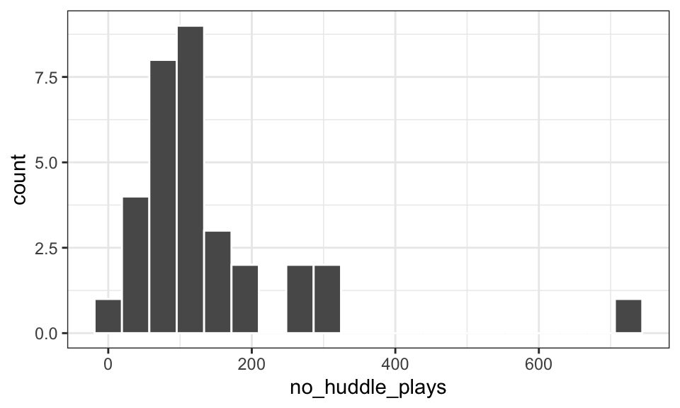

```r
ggplot(no_huddles,aes(x=no_huddle_plays))+geom_histogram(bins=20,col='white')+
  theme_bw()
```

Whoa! Washington is an outlier!

> **6.** For each team, find the proportion of no-huddle plays that were runs.

```r
no_huddles <- df |>
  filter(no_huddle == 1 ) |>
  group_by(posteam) |>
  summarize(no_huddle_plays = n(),
            run = sum(rush),
            pass = sum(pass)) |>
  arrange(desc(no_huddle_plays))

no_huddles |>
  mutate(rush_pct = round(run/(run + pass)*100,1)) |>
  arrange(desc(rush_pct)) |>
  kbl() |>
  kable_classic(full_width=F)
```

| posteam | no_huddle_plays | run | pass | rush_pct |
| --- | --- | --- | --- | --- |
| BUF | 80 | 42 | 33 | 56.0 |
| PHI | 291 | 151 | 134 | 53.0 |
| JAX | 137 | 59 | 74 | 44.4 |
| IND | 126 | 49 | 71 | 40.8 |
| BAL | 68 | 24 | 38 | 38.7 |
| WAS | 741 | 267 | 455 | 37.0 |
| CHI | 295 | 105 | 179 | 37.0 |
| DET | 45 | 14 | 27 | 34.1 |
| NE | 114 | 35 | 71 | 33.0 |
| PIT | 269 | 82 | 176 | 31.8 |
| ATL | 175 | 52 | 114 | 31.3 |
| MIN | 131 | 39 | 86 | 31.2 |
| NO | 113 | 33 | 77 | 30.0 |
| GB | 107 | 31 | 73 | 29.8 |
| ARI | 113 | 33 | 78 | 29.7 |
| SEA | 250 | 62 | 172 | 26.5 |
| DAL | 114 | 27 | 79 | 25.5 |
| MIA | 72 | 15 | 51 | 22.7 |
| DEN | 152 | 32 | 114 | 21.9 |
| NYG | 154 | 31 | 116 | 21.1 |
| LV | 129 | 25 | 98 | 20.3 |
| HOU | 62 | 12 | 48 | 20.0 |
| CAR | 75 | 14 | 60 | 18.9 |
| NYJ | 90 | 16 | 71 | 18.4 |
| CLE | 179 | 32 | 144 | 18.2 |
| TEN | 84 | 14 | 65 | 17.7 |
| LAC | 43 | 7 | 33 | 17.5 |
| LA | 97 | 16 | 78 | 17.0 |
| TB | 65 | 9 | 53 | 14.5 |
| KC | 16 | 2 | 12 | 14.3 |
| CIN | 35 | 4 | 30 | 11.8 |
| SF | 41 | 3 | 30 | 9.1 |

> **7.** How many times did a team ‘go for it’ on fourth down and 4? How often did such a team run the ball? How often did they throw it? How often were teams successful?

A table can answer the firsts question:

```r
fourth_and_4 <- df |> filter(down==4 & ydstogo == 4)

table(fourth_and_4$play_type)
```

```
##
## field_goal    no_play       pass       punt        run
##         96         25         47        148          9
```

A two-way table can answer the next two:

```r
table(fourth_and_4$play_type,
      fourth_and_4$first_down
      )
```

```
##
##                0   1
##   field_goal  96   0
##   no_play     18   7
##   pass        27  20
##   punt       148   0
##   run          1   8
```

By inspection, a run play was successful in 8 of the 9 attempts (88.9% of the time - small sample size), and pass plays were successful in 20 of the 47 attempts (42.5% of the time).

> **8.** Explore why a team might chose one play_type over the others, given the game circumstances.

One approach - consider where on the field the team is:

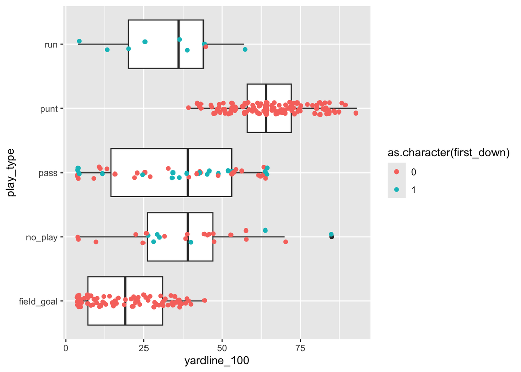

```r
ggplot(fourth_and_4)+
  geom_boxplot(aes(x=yardline_100,y=play_type))+
  geom_jitter(aes(x=yardline_100,y=play_type,col=as.character(first_down)),height=.1)
```

> **9.** Which teams had the worst/best field goal percentage for attempts under 40 yards?

```r
field_goals<-df |>
  filter(play_type=="field_goal",season_type=="REG")|>
  select(game_date,time,down,yrdln,ydstogo,yardline_100,posteam,
         defteam,field_goal_result,field_goal_attempt,
         game_seconds_remaining,ep,contains("prob"),game_id)|>
  mutate(success=ifelse(field_goal_result=="made",1,0),
         fg_distance=yardline_100+17)

short_fg_by_team <- field_goals |>
  filter(fg_distance < 40) |>
  group_by(posteam) |>
  summarize(attempts = n(),
            made = sum(success)) |>
  mutate(short_fg_pct = made/attempts)
```